# 1 Introdução

A pré-eclâmpsia, caracterizada por hipertensão arterial e danos a órgãos, é uma complicação gestacional que geralmente se manifesta após a 20ª semana de gravidez. Ela é frequentemente acompanhada de sintomas como aumento da pressão arterial, presença de proteína na urina, edema e, em casos mais graves, eclâmpsia, que pode resultar em convulsões. Esta condição não apenas representa uma ameaça direta à saúde da mãe, mas também pode ter sérias consequências para o feto, incluindo restrição de crescimento intrauterino e parto prematuro. A magnitude do problema da pré-eclâmpsia é evidente nas estatísticas globais de saúde materna. A pré-eclâmpsia é um fator de risco para complicações de saúde a longo prazo para a mãe, como doença cardíaca e hipertensão.

Neste estudo, realizamos uma análise estatística abrangente. Isso incluiu a utilização de uma análise descritiva dos dados coletados para melhor compreensão do perfil das pacientes, bem como o cálculo amostral para determinar o tamanho ideal da amostra para garantir resultados confiáveis e uso de Regressão Linear para identificar se os grupos de estudo alteram algumas variáveis contínuas de interesse que estão associadas a Função Endotelial, além de Regressão Logística para identificar se o grupo é fator de risco associado ao evento de ter ou não Síndrome Metabólica. Esta análise estatística detalhada visa aprimorar a compreensão da pré-eclâmpsia, suas causas potenciais e possíveis estratégias de prevenção, contribuindo assim para o avanço das práticas médicas e políticas de saúde relacionadas à gravidez.

Através deste estudo multidisciplinar, esperamos fornecer insights valiosos para profissionais de saúde, pesquisadores e formuladores de políticas, a fim de melhorar o diagnóstico precoce, o tratamento e a prevenção da pré-eclâmpsia, com o objetivo de promover a saúde materna e neonatal em todo o mundo.

Este trabalho tem como objetivo explorar uma ampla gama de dados relacionados às mulheres que tiveram ou não pré-eclâmpsia, incluindo características físicas, resultados de exames laboratoriais, histórico de doenças e hábitos. A pré-eclâmpsia, uma condição médica complexa que afeta mulheres grávidas, é de grande interesse para a comunidade médica devido às suas implicações para a saúde materna e neonatal.

# 2 Objetivo

## 2.1 Objetivo Geral

Conduzir uma investigação abrangente sobre a pré-eclâmpsia, incluindo planejamento amostral, análise das diferenças entre mulheres saudáveis (MN) e aquelas com pré-eclâmpsia (MP), estudo da relação entre função endotelial e síndrome metabólica com a pré-eclâmpsia, a qual é um dos principais fatores de risco para a alteração dessas variáveis.

## 2.2 Objetivos Específicos

- Realizar testes para compreender como e comportam os grupos de mulheres com e sem pré-eclâmpsia.
- Determinar como o grupo influência na alteração das funções endoteliais e metabólicas.
- Realizar o dimensionamento amostral, em que será calculado o tamanho da amostra de acordo com o erro esperado.

# 3 Metodologia

## 3.1 Variáveis utilizadas

As variáveis analisadas foram:

**Idade**

- Tipo de Variável: Numérica
- Unidades de Medida: Anos

**Escolaridade**

- Tipo de Variável: Categórica (Nível de Educação)
- Unidades de Medida: N/A
- Níveis:
  - 0 – Educação infantil
  - 1 - Fundamental
  - 2 - Médio
  - 3 - Superior
  - 4 - Pós-graduação
  - 5 - Técnico

**Número de Gestações**

- Tipo de Variável: Numérica
- Unidades de Medida: N/A

**Anos Desde a Última Gestação**

- Tipo de Variável: Numérica
- Unidades de Medida: Anos

**Peso da Mulher**

- Tipo de Variável: Numérica
- Unidades de Medida: Kilogramas

**Índice de Massa Corporal (IMC)**

- Tipo de Variável: Numérica
- Unidades de Medida: N/A

**Percentual de Gordura**

- Tipo de Variável: Numérica
- Unidades de Medida: Porcentagem

**Pressão Sistólica**

- Tipo de Variável: Numérica
- Unidades de Medida: mmHg (milímetros de mercúrio)

**Pressão Diastólica**

- Tipo de Variável: Numérica
- Unidades de Medida: mmHg (milímetros de mercúrio)

**Pressão Arterial Média**

- Tipo de Variável: Numérica
- Unidades de Medida: mmHg (milímetros de mercúrio)

**Circunferência de Cintura**

- Tipo de Variável: Numérica
- Unidades de Medida: Centímetros

**Circunferência de Abdômen**

- Tipo de Variável: Numérica
- Unidades de Medida: Centímetros

**Circunferência de Quadril**

- Tipo de Variável: Numérica
- Unidades de Medida: Centímetros

**Relação Cintura/Quadril**

- Tipo de Variável: Numérica
- Unidades de Medida: N/A

**Neutrófilos**

- Tipo de Variável: Numérica
- Unidades de Medida: Contagem Absoluta

**Linfócitos**

- Tipo de Variável: Numérica
- Unidades de Medida: Contagem Absoluta

**Razão Neutrófilo/Linfócito (NLR)**

- Tipo de Variável: Numérica
- Unidades de Medida: N/A

**Colesterol Total**

- Tipo de Variável: Numérica
- Unidades de Medida: mg/dL (miligramas por decilitro)

**HDL (High-Density Lipoprotein/ Lipoproteína de Alta Densidade)**

- Tipo de Variável: Numérica
- Unidades de Medida: mg/dL (miligramas por decilitro)

**LDL Dosado (Low-Density Lipoprotein/ Lipoproteína de Baixa Densidade)**

- Tipo de Variável: Numérica
- Unidades de Medida: mg/dL (miligramas por decilitro)

**VLDL (Very Low-Density Lipoprotein/ Lipoproteína de Muito Baixa Densidade)**

- Tipo de Variável: Numérica
- Unidades de Medida: mg/dL (miligramas por decilitro)

**Não-HDL (Non-High-Density Lipoprotein/ Lipoproteína de Não Alta Densidade)**

- Tipo de Variável: Numérica
- Unidades de Medida: mg/dL (miligramas por decilitro)

**Triglicérides**

- Tipo de Variável: Numérica
- Unidades de Medida: mg/dL (miligramas por decilitro)

**Hemoglobina Glicada (HbA1c)**

- Tipo de Variável: Numérica
- Unidades de Medida: Porcentagem

**Creatinina**

- Tipo de Variável: Numérica
- Unidades de Medida: mg/dL (miligramas por decilitro)

**Ritmo de Filtração Glomerular**

- Tipo de Variável: Numérica
- Unidades de Medida: mL/min (mililitros por minuto)

**TGP/ALT (Transaminase Glutâmica Pirúvica / Alanina Transaminase)**

- Tipo de Variável: Numérica
- Unidades de Medida: U/L (unidades por litro)

**TGO/AST (Transaminase Glutâmica Oxalacética / Aspartato Transaminase)**

- Tipo de Variável: Numérica
- Unidades de Medida: U/L (unidades por litro)

**Ácido Úrico**

- Tipo de Variável: Numérica
- Unidades de Medida: mg/dL (miligramas por decilitro)

**CK (Creatina Quinase)**

- Tipo de Variável: Numérica
- Unidades de Medida: U/L (unidades por litro)

**Gama GT (Gama Glutamiltransferase)**

- Tipo de Variável: Numérica
- Unidades de Medida: U/L (unidades por litro)

**Peso do Bebê**

- Tipo de Variável: Numérica
- Unidades de Medida: Kilogramas

**PAI-1 (Inibidor-1 do Ativador de Plasminogênio)**

- Tipo de Variável: Numérica
- Unidades de Medida: ng/mL (nanogramas por mililitro)

**Trombomodulina**

- Tipo de Variável: Numérica
- Unidades de Medida: ng/mL (nanogramas por mililitro)

**ADMA (Asymmetric Dimethylarginine/ Dimetilarginina assimétrica)**

- Tipo de Variável: Numérica
- Unidades de Medida: ng/mL (nanogramas por mililitro)

**sFlt1 (Soluble Fms-Like Tyrosine Kinase-1)**

- Tipo de Variável: Numérica
- Unidades de Medida: N/A (cálculos necessários)

**Dímero-D**

- Tipo de Variável: Numérica
- Unidades de Medida: ng/mL (nanogramas por mililitro)

**Tabagismo**

- Tipo de Variável: Categórica Nominal
- Níveis:
  - 0 – Não fumante
  - 1 - Fumante

**Grupo (em relação à pré-eclâmpsia)**

- Tipo de Variável: Categórica Nominal
- Níveis:
  - 1 – Não teve pre-eclâmpsia
  - 2 - Teve pré-eclâmpsia

## 3.2 Análises descritivas

Os resultados destas análises foram meticulosamente organizados em uma tabela resumo, proporcionando uma visão abrangente das medidas analisadas e dos resultados dos testes realizados.

Foram levantadas algumas medidas de resumo para as variáveis de interesse contidas no banco de dados. Essas descritivas foram analisadas com o objetivo de avaliar principalmente o efeito da variável em cada grupo.

Os resultados foram adicionados em uma tabela, que contém, além da variável analisada e o grupo MN ou MP, as seguintes medidas descritivas, para os dados contínuos:

- N: tamanho amostral de cada um dos grupos (valores presentes no banco de dados)
- Nulos: quantidade de valores nulos em cada um dos grupos
- Média: média do conjunto de dados em cada grupo
- DesPad: desvio padrão do conjunto de dados em cada grupo
- Min: valor mínimo do conjunto de dados em cada grupo
- Quartis: valores que dividem um conjunto de dados ordenados em partes iguais, representando porcentagens específicas da distribuição
  - Q1 – é o primeiro quartil, valor que divide os dados ordenados em que 25% das observações estão abaixo desse ponto, representando o limite inferior do primeiro quarto da distribuição
  - Mediana – também chamada de segundo quartil, é o valor central em um conjunto de dados ordenados, onde metade das observações estão abaixo e metade estão acima desse ponto, dividindo o conjunto ao meio
  - Q3 – valor que divide os dados ordenados em que 75% das observações estão abaixo desse ponto, representando o limite inferior do último quarto da distribuição
- Máx: valor máximo do conjunto de dados em cada grupo

Na tabela dos dados discretos, podemos encontrar as colunas que representam:

- Categoria: apresenta quais são as categorias da variável analisada
- MN e MP: quantidade de observações no grupo MN e MP
- MN(%) e MP(%): representam o percentual de mulheres que está no grupo, em relação ao total

## 3.3 Testes de hipóteses

Para os dados numéricos, os testes tiveram por hipótese geral:

$$\begin{eqnarray}
{
\left\{\begin{array}{lcc}
H_{0}: {\mu_{Grupo~MN} = \mu_{Grupo~MP}} \\
H_{1}: {\mu_{Grupo~MN} \neq \mu_{Grupo~MP}}
\end{array}\right.
} \nonumber
\end{eqnarray}$$

Foi feito o *Teste de Shapiro-Wilk* para avaliar se era válida a suposição de normalidade para os grupos. Foi aplicado o *Teste T* para comparação da média de dois grupos, assim como o *Teste de Mann-Whitney*, que foi aplicado como teste não paramétrico. Em suma, deseja-se avaliar se a média ou a mediana entre os grupos é igual para uma dada variável ou se há diferença. Apesar de algumas variáveis não terem atendido ao pressuposto de normalidade, os dois testes foram feitos para todas as variáveis, ficando a critério da pesquisadora uma possível padronização.

Para as variáveis qualitativas, o *Teste Qui-Quadrado* foi utilizado para tabelas de contingência, sendo aplicado sob a hipótese nula de que não há diferença significativa nas distribuições das variáveis entre os grupos, ou seja, as variáveis são independentes.

Algumas variáveis contínuas foram usadas ora como contínuas, ora como categóricas em níveis. IMC, por exemplo, foi segmentado em mulheres com *magraza/eutrofia* (imc < 24.99), *sobrepeso* (imc entre 24.99-29.99) e *obesidade* (imc > 30). O tipo de sangue também foi sugerido segmentação diferente da original em *sangue O* (caso grupo psanguíneo fosse O) e *sangue não O* (demais grupos sanguíneos), entretanto, não houve significância esse agrupamento.

Outra categorização feita foi em relação a escolaridade. Ela estava, inicialmente, dividida em 6 categorias, contidas na seção 3.1. Ela foi tratada como variável binária, contendo apenas as categorias divididas em esino básico e ensino superior. Posteriomente, ela foi dividida em 3 níveis: fundamental (ensino infantil e fundamental), médio (ensino médio e técnico) e superior (ensino superior e pós graduação). Essa maneira se mostrou mais adequada para as análises.

## 3.4 Regressões

Nas regressões, o objetivo era avaliar condições que se caracterizam como fator de risco para pré-eclâmpsia, ao avaliar se a condição altera resultados desses sinalizadores. Portanto, quando o grupo for significativo para o modelo, pode-se afirmar que ter a doença altera de maneira significativa as chances da mulher ter alterações no que está sendo avaliado.

Sabemos, pela literatura, que a pré eclampsia é caracterizada pela resposta inflamatória, lesão endotelial, agregação plaquetária, ativação do sistema de coagulação e aumento da resistência vascular generalizada, portanto, as variáveis respostas são aquelas que caracterizam essa disfunção, e espera-se que elas estejam alteradas quando a mulher apresentou pré eclâmpsia. São elas: pressão arterial sistólica (PAS), pressão arterial diastólica (PAD), pressão arterial média (PAM), índice de massa corporal (IMC), colesterol LDL, trombomodulina, ADMA e síndrome metabólica.

Como o objetivo é o estudo dos grupos e de como ele afeta as variáveis resposta, nossas variáveis independentes iniciais foram aquelas que deram significativas para o grupo. Essas variáveis podem ser encontradas na tabela resumo. Algumas delas foram excluídas por ter forte multicolinearidade, e apenas a que foi julgada mais importante deses pequenos grupos continuou no modelo.

As variáveis explicativas pertencentes a cada um dos modelos finais foram apenas aquelas consideradas estatisticamente e clinicamente significativas em relação ao que estava sendo estudado. A maioria das covariáveis inseridas, além de grupo, foram inseridas para melhorar o ajuste e entrar como métricas de perturbação, ou seja, o quanto outras variáveis, além de grupo, contribuiem ou interferem na explicação da variável resposta.

Foi usado um Modelo de Regressão Linear supondo normalidade para os resíduos, para todas as variáveis contínuas. A fim de validar as suposições, dos dados usados para variável Adma, foi retirado observações extremas, todas elas do grupo MP, e a retirada juntamente com a transformação logarítma na variável resposta contribuiu para melhorar o ajuste. Todas regressões foram significativas. Como há presença de variável categórica em *Grupo*, o grupo basal tido como referência no intercepto é o grupo MN (das mulheres saudáveis). A interpretação dos modelos lineares implica em quanto a variável aumenta/diminui em média a variável resposta. Para a variável grupo, temos que a interpretação fica: como estar no grupo MP influência no aumento ou diminuição da variável resposta em média.

Os resíduos para a maioria dos modelos seguiu a normalidade, e os pressupostos para realizar a regressão foram seguidos. A única regressão que não apresentou normalidade foi para a variável LDL Dosado, para qual oberservou-se as caudas mais pesadas, distanciando assim do modelo Normal. Entretanto, como o desvio foi apenas nas extremidades e como trata-se de uma amostra grande, considerou-se razoável em aceitar o modelo.

O coeficiente de determinação ($R^2$) em análises de regressão na área médica oferece uma medida da proporção da variabilidade na variável dependente que é explicada pelas variáveis independentes do modelo. No entanto, em estudos médicos, $R^2$ frequentemente não atinge valores elevados. Isso se deve à complexidade das interações biológicas e à presença de múltiplos fatores desconhecidos que contribuem para a variabilidade dos resultados. A natureza intrincada dessas relações pode resultar em um $R^2$ mais modesto, indicando que o modelo não consegue explicar toda a variabilidade observada, uma característica comum em pesquisas médicas devido à diversidade e complexidade dos fenômenos biológicos estudados.

## 3.5 Tamanho Amostral

Para o cálculo do tamanho da amostra onde o objetivo do estudo era validar se a amostra usada no trabalho é significativa para comparar dois grupos: grupo tratamento com um controle, no contexto do trabalho o grupo controle seriam as mulheres que tiveram gestações saudáveis *(MN)* e o grupo tratamento seriam mulheres que tiveram pré-eclâmpsia *(MP)*. Optou-se por usar a informação da variância e da diferença das médias das variáveis que foram usadas como resposta na regressão. São elas:

- PAS: indica Pressão Arterial Sitólica;
- PAD: indica Pressão Arterial Diastólica;
- PAM: indica Pressão Arterial Média;
- IMC: indica Índice de Massa Corporal;
- LDL: indica Lipoproteínas de Baixa Densidade;
- CIN: indica Circunferência da Cintura.

Como a finalidade é apenas validar, as variâncias para os grupos, denotados por $\sigma^2_{MN}$ e $\sigma^2_{MP}$, respectivamente, serão obtidas por meio da própria base de dados repassada para esse projeto. Portanto, para o cálculo, considerou-se as seguintes variâncias por grupo:

Table 3.1: Cálculo das variâncias por grupo

| Grupo | var PAS | var PAD | var PAM | var IMC | var LDL | var CIN |
| --- | --- | --- | --- | --- | --- | --- |
| MN | 200 | 125 | 123 | 22 | 1.121 | 105 |
| MP | 380 | 217 | 251 | 26 | 1.287 | 143 |

O *delta* ($\delta$) denota a diferença das médias do grupo MN e MP, $|\mu_{MN} - \mu_{MP}| < \delta$. Da mesma forma, essa informação foi retirada da base dados a fim de validação. A diferença das médias encontrada para cada caso está descrito abaixo:

Table 3.2: Cálculo da diferença das médias por grupo

| delta PAS | delta PAD | delta PAM | delta IMC | delta LDL | delta CIN |
| --- | --- | --- | --- | --- | --- |
| 11 | 9 | 10 | 2 | 22 | 3 |

Então, escolhendo um nível de significância de $\alpha = 0,05$ e variandos-se o poder de teste de ($1 - \beta$), tem-se que os resultados encontrados serão discutivos na seção de *Resultados*.

# 4 Resultados

## 4.1 Testes de Hipóteses

### 4.1.1 Dados numéricos

Para os dados numéricos, os testes tiveram os seguintes resultados:

[output not shown]

[output cut: 86 more lines]

### 4.1.2 Dados categóricos

Para os dados categóricos, os testes tiveram os seguintes resultados:

[output not shown]

## 4.2 Resultado Regressões Lineares

### 4.2.1 PAS

```
##
## Call:
## lm(formula = pressao_sis ~ grupo + idade + anti_hiper + imc +
##     escolaridade_niveis, data = df_reg)
##
## Residuals:
##     Min      1Q  Median      3Q     Max
## -35.180  -9.870  -0.183   9.202  49.006
##
## Coefficients:
##                             Estimate Std. Error t value Pr(>|t|)
## (Intercept)                  90.9291    11.3542   8.008 1.43e-13 ***
## grupo1                        5.8007     2.4755   2.343  0.02022 *
## idade                         0.4674     0.1919   2.435  0.01586 *
## anti_hiper1                   9.6290     3.2928   2.924  0.00390 **
## imc                           1.0279     0.2375   4.328 2.50e-05 ***
## escolaridade_niveismedio    -15.4092     4.8693  -3.165  0.00183 **
## escolaridade_niveissuperior -13.4008     4.9896  -2.686  0.00792 **
## ---
## Signif. codes:  0 '***' 0.001 '**' 0.01 '*' 0.05 '.' 0.1 ' ' 1
##
## Residual standard error: 15.01 on 179 degrees of freedom
##   (2 observations deleted due to missingness)
## Multiple R-squared:  0.2986, Adjusted R-squared:  0.2751
## F-statistic:  12.7 on 6 and 179 DF,  p-value: 6.336e-12
```

**Interpretação:** Mantendo as demais variáveis constantes, pertencer ao grupo1 está associado a um aumento de 5,8007 mmHg na pressão arterial em comparação com o grupo de referência. O aumento em um ano de idade implica um acréscimo de 0,4674 mmHg na pressão arterial sistólica (PAS). Tomar anti-hipertensivo continua associado a um aumento significativo de 9,6290 mmHg na PAS.

Em relação à escolaridade, observamos que ter nível médio ou superior está associado a uma diminuição na PAS. A escolaridade de nível médio está associada a uma redução de 15,4092 mmHg, enquanto a escolaridade de nível superior está associada a uma redução de 13,4008 mmHg. Portanto, as chances de apresentar níveis elevados de pressão arterial parecem ser influenciadas tanto por fatores demográficos e de saúde quanto pelo nível educacional, indicando a complexidade dessas interações no contexto da pressão arterial.

### 4.2.2 PAD

```
##
## Call:
## lm(formula = pressao_dias ~ grupo + anti_hiper + imc + idade +
##     escolaridade_niveis, data = df_reg)
##
## Residuals:
##     Min      1Q  Median      3Q     Max
## -35.536  -6.925  -0.786   7.515  30.282
##
## Coefficients:
##                             Estimate Std. Error t value Pr(>|t|)
## (Intercept)                  61.5849     8.7069   7.073 3.29e-11 ***
## grupo1                        4.7842     1.8983   2.520 0.012603 *
## anti_hiper1                   7.6692     2.5250   3.037 0.002744 **
## imc                           0.6813     0.1821   3.741 0.000247 ***
## idade                         0.3689     0.1472   2.506 0.013087 *
## escolaridade_niveismedio    -13.8279     3.7340  -3.703 0.000283 ***
## escolaridade_niveissuperior -13.6810     3.8262  -3.576 0.000449 ***
## ---
## Signif. codes:  0 '***' 0.001 '**' 0.01 '*' 0.05 '.' 0.1 ' ' 1
##
## Residual standard error: 11.51 on 179 degrees of freedom
##   (2 observations deleted due to missingness)
## Multiple R-squared:  0.311,  Adjusted R-squared:  0.2879
## F-statistic: 13.47 on 6 and 179 DF,  p-value: 1.394e-12
```

**Interpretação:** Na análise de regressão do modelo para a pressão arterial diastólica (PAD) nota-se que pertencer ao grupo1 permanece associado a um aumento de 4,78mmHg na PAD; o uso de anti-hipertensivo ainda está relacionado a um aumento de 7,66mmHg na PAD. Adicionalmente, o aumento em uma unidade de IMC agora implica um acréscimo de 0,68mmHg na PAD, enquanto o envelhecimento em um ano continua associado a um acréscimo de 0,36mmHg na PAD.

Introduzindo escolaridade, nota-se que ter nível médio ou superior está associado a uma diminuição na PAD. Especificamente, a escolaridade de nível médio está relacionada a uma redução de 13,82mmHg, e a escolaridade de nível superior está associada a uma redução de 13,68mmHg na pressão arterial diastólica.

### 4.2.3 PAM

```
##
## Call:
## lm(formula = pressao_media ~ grupo + anti_hiper + imc + idade +
##     escolaridade_niveis, data = df_reg)
##
## Residuals:
##     Min      1Q  Median      3Q     Max
## -33.083  -7.624  -0.465   7.600  36.524
##
## Coefficients:
##                             Estimate Std. Error t value Pr(>|t|)
## (Intercept)                  71.3685     8.9449   7.979 1.71e-13 ***
## grupo1                        5.1234     1.9502   2.627 0.009359 **
## anti_hiper1                   8.3231     2.5941   3.209 0.001581 **
## imc                           0.7968     0.1871   4.259 3.31e-05 ***
## idade                         0.4017     0.1512   2.657 0.008607 **
## escolaridade_niveismedio    -14.3546     3.8361  -3.742 0.000246 ***
## escolaridade_niveissuperior -13.5878     3.9309  -3.457 0.000683 ***
## ---
## Signif. codes:  0 '***' 0.001 '**' 0.01 '*' 0.05 '.' 0.1 ' ' 1
##
## Residual standard error: 11.83 on 179 degrees of freedom
##   (2 observations deleted due to missingness)
## Multiple R-squared:  0.3355, Adjusted R-squared:  0.3132
## F-statistic: 15.06 on 6 and 179 DF,  p-value: 6.331e-14
```

No novo modelo, $R^2$ foi ajustado para 31%.

**Interpretação:** Mantendo as demais variáveis constantes, pertencer ao grupo1 está associado a um aumento de 5,1234 unidades na PAM em comparação com o grupo de referência. O uso de anti-hipertensivo está significativamente associado a um aumento de 8,3231 unidades na PAM. Além disso, um acréscimo de uma unidade no índice de massa corporal (IMC) resulta em um aumento de 0,7968 unidades na PAM. A idade também desempenha um papel, onde um aumento de um ano está associado a um acréscimo de 0,4017 unidades na PAM. Introduzindo a variável escolaridade, notamos que ter nível médio ou superior está associado a uma diminuição na PAM. Especificamente, a escolaridade de nível médio está relacionada a uma redução de 14,3546 unidades, e a escolaridade de nível superior está associada a uma redução de 13,5878 unidades na PAM.

### 4.2.4 IMC

```
##
## Call:
## lm(formula = imc ~ grupo + pressao_media + triglicerides, data = df_reg[-188,
##     ])
##
## Residuals:
##     Min      1Q  Median      3Q     Max
## -10.388  -2.890  -0.531   2.685  12.828
##
## Coefficients:
##               Estimate Std. Error t value Pr(>|t|)
## (Intercept)   15.45138    2.21600   6.973 5.62e-11 ***
## grupo1         1.52396    0.65628   2.322 0.021340 *
## pressao_media  0.08886    0.02319   3.831 0.000176 ***
## triglicerides  0.01552    0.00368   4.218 3.89e-05 ***
## ---
## Signif. codes:  0 '***' 0.001 '**' 0.01 '*' 0.05 '.' 0.1 ' ' 1
##
## Residual standard error: 4.179 on 181 degrees of freedom
##   (2 observations deleted due to missingness)
## Multiple R-squared:  0.2248, Adjusted R-squared:  0.212
## F-statistic:  17.5 on 3 and 181 DF,  p-value: 5.096e-10
```

**Interpretação:** Para o modelo do IMC, uma observação influente foi tirada (188ª observação). Após o ajuste, nota-se que pertencer ao grupo MP indica aumento médio no IMC de 1,52 unidades. A cada uma unidade aumentada na pressão arterial média, há um ganho de 0,09 unidades no IMC aproximadamente. Além disso, uma unidade de aumento no triglicerides resultara num aumento de 0,015 unidades no imc médio. Todas variáveis foram significativas. Um $R^2$ de 21%.

### 4.2.5 LDL

```
##
## Call:
## lm(formula = ldl_dosado ~ grupo + idade, data = df_reg)
##
## Residuals:
##     Min      1Q  Median      3Q     Max
## -62.494 -22.399  -4.862  18.634 104.874
##
## Coefficients:
##             Estimate Std. Error t value Pr(>|t|)
## (Intercept)  50.0213    17.7623   2.816  0.00539 **
## grupo1       23.4198     5.0250   4.661 6.02e-06 ***
## idade         0.9930     0.4289   2.315  0.02169 *
## ---
## Signif. codes:  0 '***' 0.001 '**' 0.01 '*' 0.05 '.' 0.1 ' ' 1
##
## Residual standard error: 34.2 on 185 degrees of freedom
## Multiple R-squared:  0.1208, Adjusted R-squared:  0.1113
## F-statistic: 12.71 on 2 and 185 DF,  p-value: 6.735e-06
```

**Interpretação:** Para o modelo de regressão do ldl dosado, estar no grupo MP indica aumento no ldl dosado em 23,41 unidades em média. Além disso, a cada um ano acrescido na idade, resultará em aumento da variável resposta em 0,99 unidades.

### 4.2.6 Trombomodulina

```
##
## Call:
## lm(formula = trombomodulina ~ grupo + escolaridade_bin, data = df_reg)
##
## Residuals:
##      Min       1Q   Median       3Q      Max
## -1.07804 -0.38403 -0.02669  0.33850  1.55756
##
## Coefficients:
##                          Estimate Std. Error t value Pr(>|t|)
## (Intercept)                2.3424     0.1096  21.372  < 2e-16 ***
## grupo1                     0.3441     0.1274   2.700  0.00853 **
## escolaridade_binsuperior  -0.3290     0.1301  -2.529  0.01348 *
## ---
## Signif. codes:  0 '***' 0.001 '**' 0.01 '*' 0.05 '.' 0.1 ' ' 1
##
## Residual standard error: 0.558 on 77 degrees of freedom
##   (108 observations deleted due to missingness)
## Multiple R-squared:  0.1825, Adjusted R-squared:  0.1613
## F-statistic: 8.595 on 2 and 77 DF,  p-value: 0.0004274
```

**Interpretação:** Para o modelo de regressão de trombomodulina, estar no grupo MP indica aumento na concentração de trombomodulina em 0,34 unidades em média. Para escolaridade dividida em nível básico e superior, comparada ao grupo básico, mulheres com escolaridade superior indicam redução da concentração de trombomodulina em 0,32 unidades em média. Todos coeficientes foram significativos no modelo.

### 4.2.7 ADMA

Havia 4 valores maiores que 200 para adma, todos do grupo MP (com eclâmpsia). Abaixo tem-se como retirar esses casos extremos contribuiram para a melhoria de algumas estimativas iniciais. Por exemplo, o desvio padrão do grupo MP reduziu de 167 para 38. Após a retirada os dados continuaram balenceados por grupo.

[output not shown]

Além disso, utilizou uma transformação na variável resposta, ($log(adma)$) que trouxe ganhos na normalização dos resíduos e indicou $R^2_{Ajustado}$ pouco penalizado.

```
##
## Call:
## lm(formula = log(adma) ~ grupo + categoriaimc + escolaridade_niveis,
##     data = df_adma)
##
## Residuals:
##      Min       1Q   Median       3Q      Max
## -0.74265 -0.24745 -0.01032  0.27604  0.77367
##
## Coefficients:
##                             Estimate Std. Error t value Pr(>|t|)
## (Intercept)                  4.59817    0.18027  25.508   <2e-16 ***
## grupo1                       0.23069    0.09956   2.317   0.0236 *
## categoriaimcsobrepeso       -0.44262    0.12976  -3.411   0.0011 **
## categoriaimcobesidade       -0.10903    0.11065  -0.985   0.3280
## escolaridade_niveismedio    -0.24198    0.16489  -1.468   0.1469
## escolaridade_niveissuperior -0.39404    0.17298  -2.278   0.0259 *
## ---
## Signif. codes:  0 '***' 0.001 '**' 0.01 '*' 0.05 '.' 0.1 ' ' 1
##
## Residual standard error: 0.3864 on 67 degrees of freedom
## Multiple R-squared:  0.2288, Adjusted R-squared:  0.1712
## F-statistic: 3.976 on 5 and 67 DF,  p-value: 0.003228
```

**Interpretação:** para o modelo Adma, estar no grupo MP indica aumento na variável resposta em 0,23 unidades em média. Usando IMC categorizado em Normal, Sobrepeso e Obesidade, comparado ao grupo de base *Normal*, estar no grupo de sobrepeso indica redição de 0,44 unidades na concentração de ADMA em média. Estar no grupo de obesidade em relação ao grupo base indica redução da concentração de ADMA de 0,11 unidades aproximadamente. Para escolaridade subdividida em 3 níveis, em relação ao grupo base “fundamental”, estar no grupo com estudo nível “médio” indica redução de 0,24 unidades na concentração de ADMA em média. O grupo de nível “superior” indica redução de 0,39 unidades em média na variável resposta.

# 5 Síndrome Metabólica

| **Characteristic** | **OR**<sup>1</sup> | **95% CI**<sup>1</sup> | **p-value** |
| --- | --- | --- | --- |
| grupo |  |  |  |
| 0 | — | — |  |
| 1 | 3.56 | 0.81, 19.1 | 0.10 |
| imc | 1.33 | 1.14, 1.64 | 0.001 |

<sup>1</sup> OR = Odds Ratio, CI = Confidence Interval

**Interpretação:** sobre o modelo de Síndrome Metabólica, retirou-se as mesmas observações de adma que eram extremas. Por ser um modelo logístico a interpretação se dá por razão de chances, logo, estar no grupo MP indica aumento de 256% na chance de ter síndrome metabólica. O IMC, por sua vez, um aumento de uma unidade no IMC indica aumento de chance de ter síndrome metabólica em 33%. Nsse modelo, grupo é significativo apenas para um $\alpha = 0,10$.

## 5.1 Resultado Cálculo Amostral

Optou-se por variar o $\beta$ no estudo ($1-\beta$ indica o poder do teste). Testes mais poderosos implicam em maior rigor do tamanho amostral, espera-se aumento do tamanho da amostra quando avaliar isso. Vale lembrar que usualmente usa-se o poder de 90%.

Os Resultados obtidos estão abaixo:

Table 5.1: Cálculo do tamanho amostral para PAS

| Poder | Tamanho por grupo | Tamanho Amostral Total |
| --- | --- | --- |
| 99% | 90 | 180 |
| 95% | 64 | 128 |
| 90% | 52 | 104 |

Table 5.1: Cálculo do tamanho amostral para PAD

| Poder | Tamanho por grupo | Tamanho Amostral Total |
| --- | --- | --- |
| 99% | 79 | 158 |
| 95% | 56 | 112 |
| 90% | 45 | 90 |

Table 5.1: Cálculo do tamanho amostral para PAM

| Poder | Tamanho por grupo | Tamanho Amostral Total |
| --- | --- | --- |
| 99% | 75 | 150 |
| 95% | 53 | 106 |
| 90% | 43 | 86 |

Table 5.1: Cálculo do tamanho amostral para IMC

| Poder | Tamanho por grupo | Tamanho Amostral Total |
| --- | --- | --- |
| 99% | 243 | 486 |
| 95% | 172 | 344 |
| 90% | 139 | 278 |

Table 5.1: Cálculo do tamanho amostral para LDL

| Poder | Tamanho por grupo | Tamanho Amostral Total |
| --- | --- | --- |
| 99% | 88 | 176 |
| 95% | 62 | 124 |
| 90% | 50 | 100 |

Table 5.1: Cálculo do tamanho amostral para CINTURA

[output not shown]

# 6 Referências

http://ndl.ethernet.edu.et/bitstream/123456789/15304/1/9103.pdf

# 7 Apêndice

- Resíduo modelo PAS

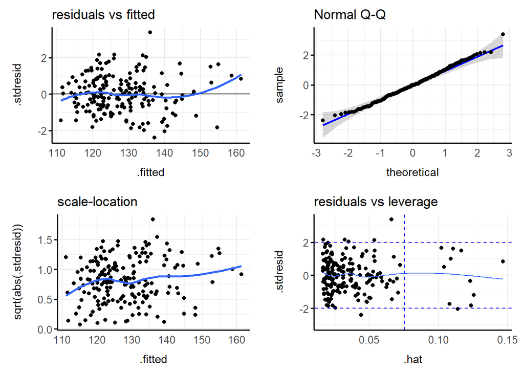

| Modelo | Pvalor |
| --- | --- |
| Modelo Pressão Sistólica | 0.64 |

- Resíduo modelo PAD

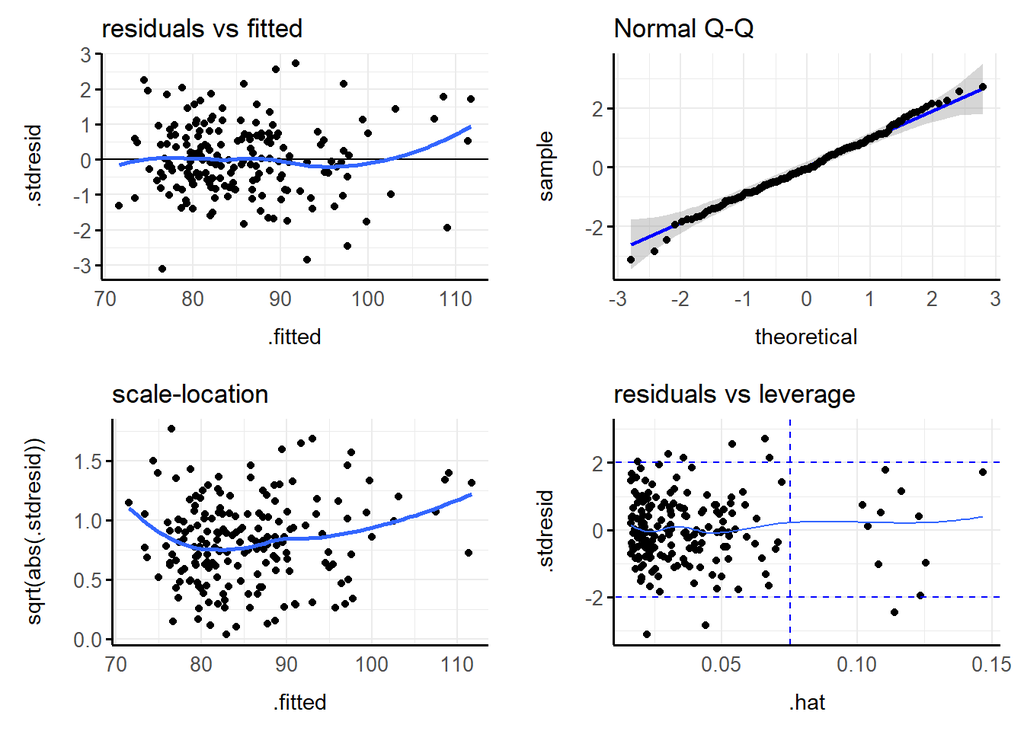

| Modelo | Pvalor |
| --- | --- |
| Modelo Pressão Diastólica | 0.774 |

- Resíduo modelo PAM

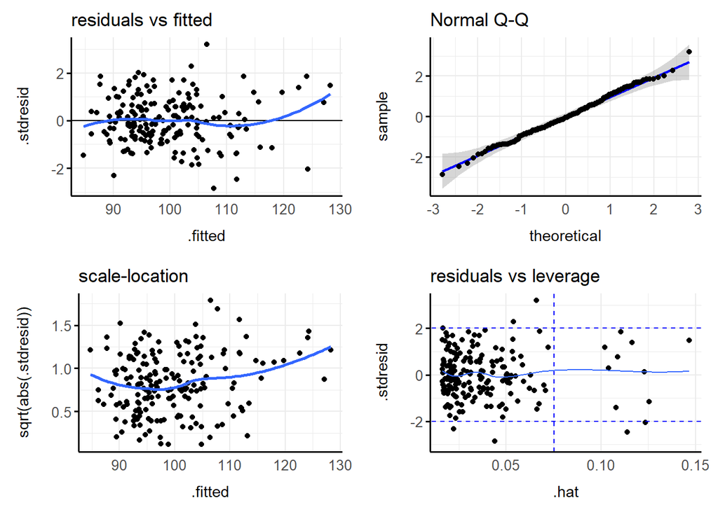

| Modelo | Pvalor |
| --- | --- |
| Modelo Pressão Média | 0.913 |

- Resíduo modelo IMC

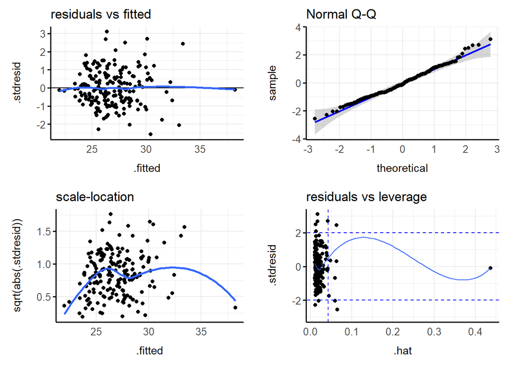

| Modelo | Pvalor |
| --- | --- |
| Modelo IMC | 0.164 |

- Resíduo modelo LDL dosado

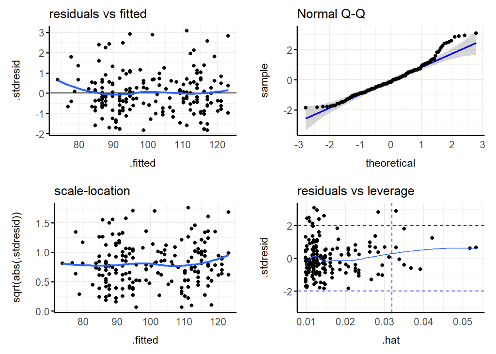

| Modelo | Pvalor |
| --- | --- |
| Modelo LDL Dosado | 0 |

- Resíduo Trombomodulina

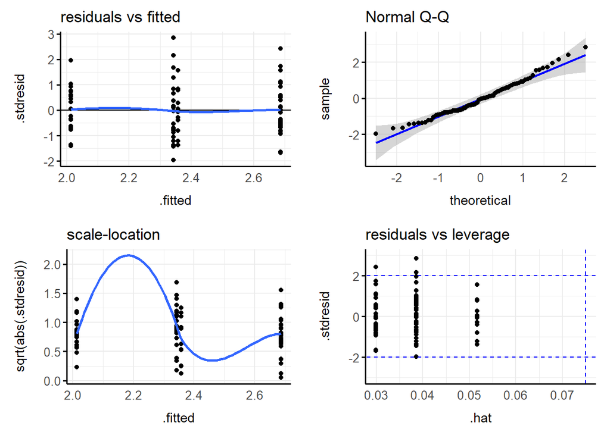

| Modelo | Pvalor |
| --- | --- |
| Modelo Trombomodulina | 0.168 |

- Resíduo Adma

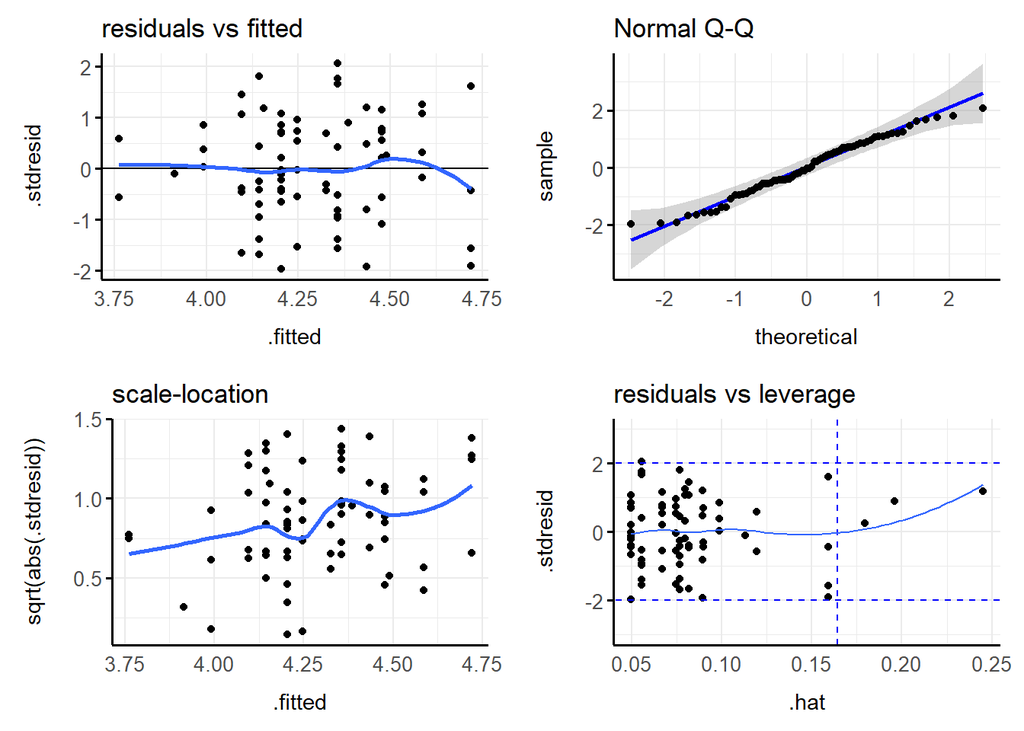

[output not shown]

- Resíduo modelo Síndrome Metabólica

```
## Binomial model
```

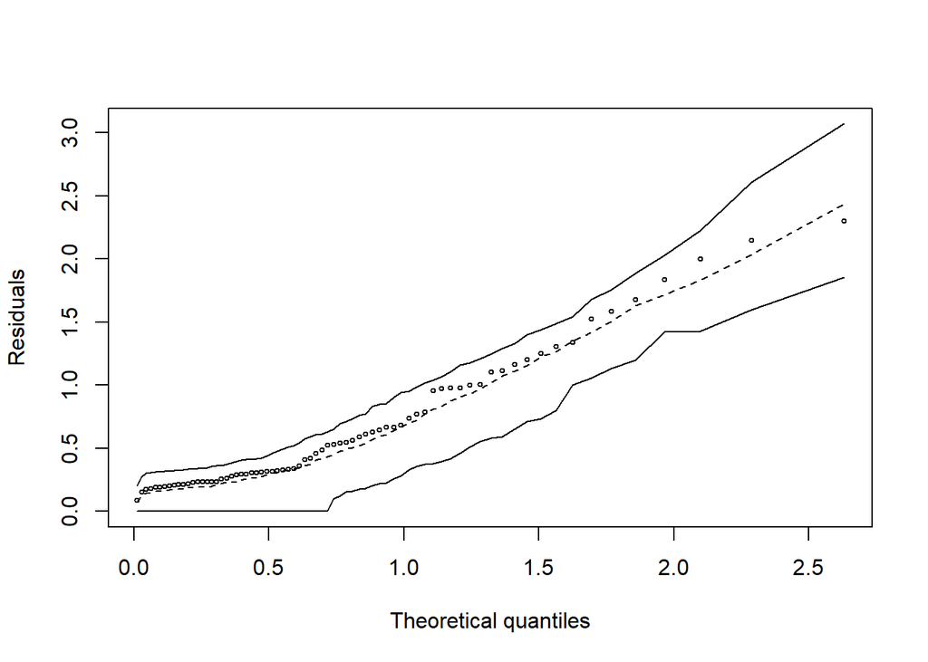